# Part I - Ford GoBike System Data

## by Anžela Filomena Minosi

- Introduction
- Functions & Variables
- Preliminary Wrangling
- Dataset
- Univariate Exploration
- Bivariate Exploration
- Multivariate Exploration
- Insights

## Introduction

> I chose the **Ford GoBike System Data** dataset covering the greater San Francisco Bay area. The data was collected during bike rides where the bikes came from a bike-sharing company. The dataset covers the years 2017 - 2019 and was downloaded on this site: https://s3.amazonaws.com/fordgobike-data/index.html. Not only does this dataset provide data on when a ride was made and how long it took but also start and end stations, which gender the users have, their year of birth and whether they had an annual subscription or not. After heaving cleaned the dataset, there are now 2,570,833 rows which are subject for my data analysis.

## Functions & Variables

```python
# import all packages and set plots to be embedded inline
import numpy as np
import pandas as pd
import matplotlib as mpl
import matplotlib.pyplot as plt
import seaborn as sb
import requests
import zipfile
import os
import glob
import datetime
from matplotlib.gridspec import  GridSpec

%matplotlib inline
```

```python
# setting the maximum number of columns and rows that should be displayed
pd.set_option('display.max_columns', None)
pd.set_option('display.max_rows', 1000)
```

```python
# the name of the cleaned dataset
merged_file='2017-2019_fordgobike_tripdata.csv'
```

```python
# Variables for the dataset
st='start_time'
et='end_time'
ut='user_type'
mg='member_gender'
bs='bike_share_for_all_trip'
mby='member_birth_year'
sh='start_hour'
swn='start_weekday_name'
smn='start_month_name'
sm='start_month'
sw='start_weekday'
ds='duration_sec'
si='start_station_id'
ei='end_station_id'
dis='difference_station'
bi='bike_id'
p_label="palette"
col_label="column"
data_label='data'
lab='label'
color_label='color'
ax_label='ax'
cat_label='cat'
loc_label='loc'
ncol_label='num_cols'
x_title='xlabel'
rot_label='rotation'
```

```python
# Variables for the charts
by='Year of Birth'
freq='Frequency'
cat_customer='Customer Type'
hour='Hour'
wd='Weekday'
m='Month'
dst='Duration in seconds'
nt='Number of Trips'
ns='Number of Stations'
sit='Start Station ID'
eit='End Station ID'
dist='Difference between start and end station'
mgt='Gender'
t1='Do customers and subscribers start their bike rides at different hours?'
t2='Do customers and subscribers start and end their bike rides at different stations?'
t3='Do customers and subscribers start their bike rides at different stations?'
t4='How does the birth year of the customers affect the duration of a trip?'
t5='Distribution of the Year of Birth of the Customers'
t6='Distribution of the Start Hour'
t7='Distribution of the Weekdays'
t8='Distribution of Gender'
t9='Distribution of Customers'
t10='Distribution of the Months between 2018 - 2019'
t11='Distribution of the Duration in Seconds'
t12='Distribution of the Start Station IDs'
t13='Distribution of the End Station IDs'
t14=dst+' across '+hour.lower()
t15=dst+' against difference in station ids'
t16=sit + 's across '+wd.lower()+'s '
t17=eit + 's across '+wd.lower()+'s '
t18='Start Time across '+cat_customer+'s'
t19=wd+'s across '+mgt
t20=m+'s across '+mgt
t21='Average of '+dst.lower()+' by '+wd.lower()+'s and '+cat_customer.lower()+'s '
t22='Distribution of '+dst.lower()+' across '+wd.lower()+'s by '+cat_customer.lower()
t23='Relationship between'+dst.lower()+' '+hour.lower()+' and the '+ sit.lower()
```

```python
# To datetime
def my_to_datetime(d,col):
    d[col] = pd.to_datetime(d[col])
```

```python
# to category
def to_category(d,col):
    d[col] = d[col].astype('category')
```

```python
# to integer
def to_int(d,col):
    d[col] = d[col].astype(int)
```

```python
# to boolean
def to_boolean(x,col):
    x[col] = x[col].astype('bool')
```

```python
# returns the weekday
def get_weekday(x):
    return x.date().strftime("%A")
```

```python
# returns the month
def get_month(x):
    return x.date().strftime("%B")
```

```python
# returns a list of tupels
def get_tuple(tuples,l):
    new_list=[]
    for i, yval in enumerate(l):
        index,xval = tuples[i]
        new_list.append((xval,yval))
    return new_list
```

```python
def display_values(x,col):
    return x.groupby(col).count()
```

```python
def get_number_nulls(x,col):
    return sum(x[col].isnull())
```

```python
def get_number_rows(x):
    return x.shape[0]
```

```python
# filters out rows where a specific column contains nulls
def get_new_dataframe(x,col):
    x2 = x[x[col].notna()]
    return x2
```

```python
# returns a list of the number of values found in a specific column
def get_value_counts(x,col):
    return x[col].value_counts()
```

```python
# plots a pie chart
def draw_pie_chart(x,col,t):
    counts = x[col].value_counts()
    plt.pie(counts, labels = counts.index, startangle = 90, counterclock = False)
    plt.title(t)
    plt.axis('square');
```

```python
# plots a bar chart
def draw_bar_chart(p,xval,x,l,c):
    sb.set_color_codes(p)
    sb.countplot(x=xval,data=x,label=l,color=c)
```

```python
# plots a bar chart
def draw_bar_chart_v2(a,x,xval,cat,p,l,n,xt,r):
    sb.countplot(ax=a,data = x, x = xval, hue = cat, palette = p)
    a.legend(loc=l,ncol = n)
    a.set_xlabel(xt)
    a.tick_params(axis='x', labelrotation=r )
```

```python
# creates a dictionary
def get_dict(p,col,x,l,c):
    my_dict = {p_label:p, col_label:col,data_label:x,lab:l,color_label:c}
    return my_dict
```

```python
# creates a dictionary
def get_dict2(a,x,xval,h,p,l,n,xt,r):
    my_dict={ax_label:a,data_label:x,col_label:xval,cat_label:h,p_label:p,loc_label:l,ncol_label:n,x_title:xt,rot_label:r}
    return my_dict
```

```python
# creates standard bins
def get_standard_bins(min_value,x,col,binsize):
    bins = np.arange(min_value, x[col].max()+binsize, binsize)
    return bins
```

```python
# creates log scaled bins
def get_log_bins(x,col,log_binsize):
    bins = 10 ** np.arange(2.4, np.log10(x[col].max())+log_binsize, log_binsize)
    return bins
```

```python
# creates standard histogram
def get_standard_histogram(bins,x_size,y_size,x,col,xt,yt,t,ax):
    plt.figure(figsize=[x_size, y_size])
    plt.hist(data = x, x = col, bins = bins)
    plt.xlabel(xt)
    plt.ylabel(yt)
    if len(ax) > 0:
        plt.axis(ax)
    plt.title(t)
    plt.show()
```

```python
# creates log scaled histogram
def get_log_histogram(bins,x_size,y_size,x,col,xt,yt,t,ax):
    plt.figure(figsize=[x_size, y_size])
    plt.hist(data = x, x = col, bins = bins)
    plt.xlabel(xt)
    plt.ylabel(yt)
    plt.axis(ax)
    plt.title(t)
    plt.xscale('log')
    plt.show()
```

```python
# creates a heat plot
def draw_heatplot(x,xval,yval,xt,yt,t):
    plt.hist2d(data =x, x = xval, y = yval, cmap='viridis_r',norm=mpl.colors.LogNorm())
    plt.colorbar()
    plt.xlabel(xt)
    plt.ylabel(yt)
    plt.title(t);
```

```python
# creates a heat plot
def draw_heatplot(x,yval,xval,xt,yt,t):
    x_counts = x.groupby([yval, xval]).size()
    x_counts = x_counts.reset_index(name=freq)
    x_counts = x_counts.pivot(index = yval, columns = xval, values = freq)
    sb.heatmap(x_counts)
    plt.xlabel(xt)
    plt.ylabel(yt)
    plt.title(t);
```

```python
# creates a violin plot
def draw_violin_plot(x,xval,yval,c,xt,yt,t):
    sb.violinplot(data=x, x=xval, y=yval, color=c,inner='quartile')
    plt.xticks(rotation=20)
    plt.xlabel(xt)
    plt.ylabel(yt)
    plt.title(t);
```

```python
# plots a regression model
def draw_regression(xval,yval,x,cat,p,a,l,xt,yt,t):
    sb.lmplot( x=xval, y=yval, data=x, fit_reg=False, hue=cat, legend=False, palette=p, scatter_kws={"alpha":a,"s":15} )
    plt.legend(loc=l, markerscale=2)
    plt.xlabel(xt)
    plt.ylabel(yt)
    plt.title(t, loc='left')
    plt.show()
```

```python
# filters the dataframe based on start time
def filter_dataframe(x,val1,val2):
    x_new = x[(x[st] >= val1 ) & (x[st] <= val2)]
    return x_new
```

## Preliminary Wrangling

> This document explores a dataset containing duration in seconds and other features for approximately 3 million bike trips.

```python
# Make directory if it doesn't already exist
folder_name = 'fordgobike'
if not os.path.exists(folder_name):
    os.makedirs(folder_name)
```

```python
# urls of zip files
urls=['https://s3.amazonaws.com/fordgobike-data/201801-fordgobike-tripdata.csv.zip',
      'https://s3.amazonaws.com/fordgobike-data/201802-fordgobike-tripdata.csv.zip',
      'https://s3.amazonaws.com/fordgobike-data/201803-fordgobike-tripdata.csv.zip',
      'https://s3.amazonaws.com/fordgobike-data/201804-fordgobike-tripdata.csv.zip',
      'https://s3.amazonaws.com/fordgobike-data/201805-fordgobike-tripdata.csv.zip',
      'https://s3.amazonaws.com/fordgobike-data/201806-fordgobike-tripdata.csv.zip',
      'https://s3.amazonaws.com/fordgobike-data/201807-fordgobike-tripdata.csv.zip',
      'https://s3.amazonaws.com/fordgobike-data/201808-fordgobike-tripdata.csv.zip',
      'https://s3.amazonaws.com/fordgobike-data/201809-fordgobike-tripdata.csv.zip',
      'https://s3.amazonaws.com/fordgobike-data/201810-fordgobike-tripdata.csv.zip',
      'https://s3.amazonaws.com/fordgobike-data/201811-fordgobike-tripdata.csv.zip',
      'https://s3.amazonaws.com/fordgobike-data/201812-fordgobike-tripdata.csv.zip',
      'https://s3.amazonaws.com/fordgobike-data/201901-fordgobike-tripdata.csv.zip',
      'https://s3.amazonaws.com/fordgobike-data/201902-fordgobike-tripdata.csv.zip',
      'https://s3.amazonaws.com/fordgobike-data/201903-fordgobike-tripdata.csv.zip',
      'https://s3.amazonaws.com/fordgobike-data/201904-fordgobike-tripdata.csv.zip']
```

```python
# downloads all zip files that are mentioned in the list:
for url in urls:
    response = requests.get(url)
    with open(os.path.join(folder_name, url.split('/')[-1]), mode = 'wb') as file:
        file.write(response.content)
```

```python
# Extracts all contents from zip file
all_files = glob.glob(folder_name + "/*.zip")
for f in all_files:
    with zipfile.ZipFile(f, 'r') as myzip:
        myzip.extractall(path=file_path)
```

```python
# downloads 2017 archive:
f = '2017-fordgobike-tripdata.csv'
url = 'https://s3.amazonaws.com/fordgobike-data/2017-fordgobike-tripdata.csv'
response = requests.get(url)
with open(folder_name + "/"+f, mode='wb') as file:
    file.write(response.content)
```

```python
# merges all csv file into one dataframe
all_files = glob.glob(folder_name + "/*.csv")
li = []
for filename in all_files:
    df = pd.read_csv(filename, index_col=None, header=0)
    li.append(df)
fordgobike = pd.concat(li, axis=0, ignore_index=True)
```

```python
# displays the columns and their datatypes
fordgobike.info()
```

```
<class 'pandas.core.frame.DataFrame'>
RangeIndex: 3254325 entries, 0 to 3254324
Data columns (total 16 columns):
 #   Column                   Dtype
---  ------                   -----
 0   duration_sec             int64
 1   start_time               object
 2   end_time                 object
 3   start_station_id         float64
 4   start_station_name       object
 5   start_station_latitude   float64
 6   start_station_longitude  float64
 7   end_station_id           float64
 8   end_station_name         object
 9   end_station_latitude     float64
 10  end_station_longitude    float64
 11  bike_id                  int64
 12  user_type                object
 13  member_birth_year        float64
 14  member_gender            object
 15  bike_share_for_all_trip  object
dtypes: float64(7), int64(2), object(7)
memory usage: 397.3+ MB
```

```python
# shows n random rows of the dataframe
fordgobike.sample(10)
```

|  | duration_sec | start_time | end_time | start_station_id | start_station_name | start_station_latitude | start_station_longitude | end_station_id | end_station_name | end_station_latitude | end_station_longitude | bike_id | user_type | member_birth_year | member_gender | bike_share_for_all_trip |
| --- | --- | --- | --- | --- | --- | --- | --- | --- | --- | --- | --- | --- | --- | --- | --- | --- |
| 2501296 | 1778 | 2017-07-23 14:03:39.1520 | 2017-07-23 14:33:17.8220 | 233.0 | 12th St at 4th Ave | 37.795812 | -122.255555 | 195.0 | Bay Pl at Vernon St | 37.812314 | -122.260779 | 1316 | Customer | NaN | NaN | NaN |
| 3000632 | 583 | 2018-05-29 07:30:55.9120 | 2018-05-29 07:40:39.2170 | 75.0 | Market St at Franklin St | 37.773793 | -122.421239 | 67.0 | San Francisco Caltrain Station 2 (Townsend St... | 37.776639 | -122.395526 | 2818 | Subscriber | 1981.0 | Male | No |
| 2403447 | 459 | 2017-08-31 16:59:18.4670 | 2017-08-31 17:06:58.1800 | 182.0 | 19th Street BART Station | 37.809013 | -122.268247 | 178.0 | Broadway at 30th St | 37.819381 | -122.261928 | 2627 | Subscriber | 1976.0 | Male | NaN |
| 319515 | 244 | 2018-06-02 11:00:44.6210 | 2018-06-02 11:04:49.3470 | 127.0 | Valencia St at 21st St | 37.756708 | -122.421025 | 123.0 | Folsom St at 19th St | 37.760594 | -122.414817 | 3846 | Subscriber | 1975.0 | Male | No |
| 2526924 | 592 | 2017-07-05 08:57:38.7150 | 2017-07-05 09:07:31.6470 | 30.0 | San Francisco Caltrain (Townsend St at 4th St) | 37.776598 | -122.395282 | 5.0 | Powell St BART Station (Market St at 5th St) | 37.783899 | -122.408445 | 588 | Subscriber | 1984.0 | Male | NaN |
| 2920213 | 642 | 2019-01-12 13:16:06.0200 | 2019-01-12 13:26:48.3050 | 52.0 | McAllister St at Baker St | 37.777416 | -122.441838 | 85.0 | Church St at Duboce Ave | 37.770083 | -122.429156 | 5489 | Subscriber | 1974.0 | Male | Yes |
| 1923757 | 1385 | 2018-09-15 14:57:54.8980 | 2018-09-15 15:21:00.3960 | 15.0 | San Francisco Ferry Building (Harry Bridges Pl... | 37.795392 | -122.394203 | 63.0 | Bryant St at 6th St | 37.775910 | -122.402575 | 1699 | Customer | NaN | NaN | No |
| 3036895 | 350 | 2018-05-22 08:22:44.1290 | 2018-05-22 08:28:34.3230 | 129.0 | Harrison St at 20th St | 37.758862 | -122.412544 | 108.0 | 16th St Mission BART | 37.764710 | -122.419957 | 3911 | Subscriber | 1983.0 | Female | No |
| 1740289 | 366 | 2018-02-22 17:40:37.0390 | 2018-02-22 17:46:43.8920 | 110.0 | 17th & Folsom Street Park (17th St at Folsom St) | 37.763708 | -122.415204 | 115.0 | Jackson Playground | 37.765026 | -122.398773 | 477 | Subscriber | 1982.0 | Male | No |
| 2040168 | 187 | 2017-12-18 08:47:12.5130 | 2017-12-18 08:50:19.6060 | 43.0 | San Francisco Public Library (Grove St at Hyde... | 37.778768 | -122.415929 | 59.0 | S Van Ness Ave at Market St | 37.774814 | -122.418954 | 2123 | Subscriber | 1982.0 | Male | NaN |

```python
# number of unique bike ids
fordgobike.bike_id.nunique()
```

```
6930
```

```python
# displays the values of the 'bike_share_for_all_trip' column
display_values(fordgobike,bs)
```

| bike_share_for_all_trip | duration_sec | start_time | end_time | start_station_id | start_station_name | start_station_latitude | start_station_longitude | end_station_id | end_station_name | end_station_latitude | end_station_longitude | bike_id | user_type | member_birth_year | member_gender |
| --- | --- | --- | --- | --- | --- | --- | --- | --- | --- | --- | --- | --- | --- | --- | --- |
| No | 2495879 | 2495879 | 2495879 | 2484253 | 2484253 | 2495879 | 2495879 | 2484253 | 2484253 | 2495879 | 2495879 | 2495879 | 2495879 | 2344258 | 2344612 |
| Yes | 238746 | 238746 | 238746 | 237871 | 237871 | 238746 | 238746 | 237871 | 237871 | 238746 | 238746 | 238746 | 238746 | 238742 | 238742 |

```python
# number of nulls in 'bike_share_for_all_trip' column which is because of the 2017's dataset that lacks this column
get_number_nulls(fordgobike,bs)
```

```
519700
```

```python
# displays all values of the 'start_station_id' column
display_values(fordgobike,si)
```

| start_station_id | duration_sec | start_time | end_time | start_station_name | start_station_latitude | start_station_longitude | end_station_id | end_station_name | end_station_latitude | end_station_longitude | bike_id | user_type | member_birth_year | member_gender | bike_share_for_all_trip |
| --- | --- | --- | --- | --- | --- | --- | --- | --- | --- | --- | --- | --- | --- | --- | --- |
| 3.0 | 54947 | 54947 | 54947 | 54947 | 54947 | 54947 | 54947 | 54947 | 54947 | 54947 | 54947 | 54947 | 49128 | 49128 | 44805 |
| 4.0 | 11716 | 11716 | 11716 | 11716 | 11716 | 11716 | 11716 | 11716 | 11716 | 11716 | 11716 | 11716 | 9817 | 9817 | 9188 |
| 5.0 | 44717 | 44717 | 44717 | 44717 | 44717 | 44717 | 44717 | 44717 | 44717 | 44717 | 44717 | 44717 | 40480 | 40480 | 36730 |
| 6.0 | 57546 | 57546 | 57546 | 57546 | 57546 | 57546 | 57546 | 57546 | 57546 | 57546 | 57546 | 57546 | 47697 | 47697 | 43882 |
| 7.0 | 15383 | 15383 | 15383 | 15383 | 15383 | 15383 | 15383 | 15383 | 15383 | 15383 | 15383 | 15383 | 14522 | 14522 | 12448 |
| 8.0 | 19249 | 19249 | 19249 | 19249 | 19249 | 19249 | 19249 | 19249 | 19249 | 19249 | 19249 | 19249 | 15190 | 15190 | 14980 |
| 9.0 | 18174 | 18174 | 18174 | 18174 | 18174 | 18174 | 18174 | 18174 | 18174 | 18174 | 18174 | 18174 | 16670 | 16670 | 13989 |
| 10.0 | 14033 | 14033 | 14033 | 14033 | 14033 | 14033 | 14033 | 14033 | 14033 | 14033 | 14033 | 14033 | 11734 | 11734 | 11723 |
| 11.0 | 17751 | 17751 | 17751 | 17751 | 17751 | 17751 | 17751 | 17751 | 17751 | 17751 | 17751 | 17751 | 16691 | 16691 | 14277 |
| 13.0 | 15611 | 15611 | 15611 | 15611 | 15611 | 15611 | 15611 | 15611 | 15611 | 15611 | 15611 | 15611 | 14704 | 14704 | 12218 |
| 14.0 | 19363 | 19363 | 19363 | 19363 | 19363 | 19363 | 19363 | 19363 | 19363 | 19363 | 19363 | 19363 | 17966 | 17966 | 15434 |
| 15.0 | 67991 | 67991 | 67991 | 67991 | 67991 | 67991 | 67991 | 67991 | 67991 | 67991 | 67991 | 67991 | 57953 | 57960 | 52804 |
| 16.0 | 49017 | 49017 | 49017 | 49017 | 49017 | 49017 | 49017 | 49017 | 49017 | 49017 | 49017 | 49017 | 46026 | 46031 | 39670 |
| 17.0 | 37898 | 37898 | 37898 | 37898 | 37898 | 37898 | 37898 | 37898 | 37898 | 37898 | 37898 | 37898 | 35803 | 35810 | 30249 |
| 18.0 | 3822 | 3822 | 3822 | 3822 | 3822 | 3822 | 3822 | 3822 | 3822 | 3822 | 3822 | 3822 | 3639 | 3639 | 3229 |
| 19.0 | 26666 | 26666 | 26666 | 26666 | 26666 | 26666 | 26666 | 26666 | 26666 | 26666 | 26666 | 26666 | 24843 | 24843 | 21824 |
| 20.0 | 22234 | 22234 | 22234 | 22234 | 22234 | 22234 | 22234 | 22234 | 22234 | 22234 | 22234 | 22234 | 20728 | 20728 | 17578 |
| 21.0 | 56920 | 56920 | 56920 | 56920 | 56920 | 56920 | 56920 | 56920 | 56920 | 56920 | 56920 | 56920 | 52913 | 52913 | 45586 |
| 22.0 | 47053 | 47053 | 47053 | 47053 | 47053 | 47053 | 47053 | 47053 | 47053 | 47053 | 47053 | 47053 | 45563 | 45733 | 37127 |
| 23.0 | 28745 | 28745 | 28745 | 28745 | 28745 | 28745 | 28745 | 28745 | 28745 | 28745 | 28745 | 28745 | 26925 | 26951 | 22765 |
| 24.0 | 22874 | 22874 | 22874 | 22874 | 22874 | 22874 | 22874 | 22874 | 22874 | 22874 | 22874 | 22874 | 21796 | 21797 | 18076 |
| 25.0 | 19018 | 19018 | 19018 | 19018 | 19018 | 19018 | 19018 | 19018 | 19018 | 19018 | 19018 | 19018 | 18076 | 18076 | 13286 |
| 26.0 | 12253 | 12253 | 12253 | 12253 | 12253 | 12253 | 12253 | 12253 | 12253 | 12253 | 12253 | 12253 | 11448 | 11448 | 10367 |
| 27.0 | 30114 | 30114 | 30114 | 30114 | 30114 | 30114 | 30114 | 30114 | 30114 | 30114 | 30114 | 30114 | 29030 | 29030 | 25921 |
| 28.0 | 21645 | 21645 | 21645 | 21645 | 21645 | 21645 | 21645 | 21645 | 21645 | 21645 | 21645 | 21645 | 19289 | 19289 | 16895 |
| 29.0 | 7136 | 7136 | 7136 | 7136 | 7136 | 7136 | 7136 | 7136 | 7136 | 7136 | 7136 | 7136 | 6515 | 6515 | 5874 |
| 30.0 | 59937 | 59937 | 59937 | 59937 | 59937 | 59937 | 59937 | 59937 | 59937 | 59937 | 59937 | 59937 | 57379 | 57379 | 47391 |
| 31.0 | 8741 | 8741 | 8741 | 8741 | 8741 | 8741 | 8741 | 8741 | 8741 | 8741 | 8741 | 8741 | 7791 | 7791 | 7164 |
| 33.0 | 7003 | 7003 | 7003 | 7003 | 7003 | 7003 | 7003 | 7003 | 7003 | 7003 | 7003 | 7003 | 6515 | 6515 | 5512 |
| 34.0 | 6990 | 6990 | 6990 | 6990 | 6990 | 6990 | 6990 | 6990 | 6990 | 6990 | 6990 | 6990 | 6495 | 6495 | 5695 |

[output cut: 342 more lines]

```python
# displays all values of the 'end_station_id' column
display_values(fordgobike,ei)
```

| end_station_id | duration_sec | start_time | end_time | start_station_id | start_station_name | start_station_latitude | start_station_longitude | end_station_name | end_station_latitude | end_station_longitude | bike_id | user_type | member_birth_year | member_gender | bike_share_for_all_trip |
| --- | --- | --- | --- | --- | --- | --- | --- | --- | --- | --- | --- | --- | --- | --- | --- |
| 3.0 | 57743 | 57743 | 57743 | 57743 | 57743 | 57743 | 57743 | 57743 | 57743 | 57743 | 57743 | 57743 | 52250 | 52250 | 46679 |
| 4.0 | 11628 | 11628 | 11628 | 11628 | 11628 | 11628 | 11628 | 11628 | 11628 | 11628 | 11628 | 11628 | 9849 | 9849 | 9066 |
| 5.0 | 46403 | 46403 | 46403 | 46403 | 46403 | 46403 | 46403 | 46403 | 46403 | 46403 | 46403 | 46403 | 41918 | 41918 | 37840 |
| 6.0 | 68159 | 68159 | 68159 | 68159 | 68159 | 68159 | 68159 | 68159 | 68159 | 68159 | 68159 | 68159 | 53888 | 53888 | 51628 |
| 7.0 | 15326 | 15326 | 15326 | 15326 | 15326 | 15326 | 15326 | 15326 | 15326 | 15326 | 15326 | 15326 | 14472 | 14472 | 12196 |
| 8.0 | 20176 | 20176 | 20176 | 20176 | 20176 | 20176 | 20176 | 20176 | 20176 | 20176 | 20176 | 20176 | 15990 | 15990 | 15795 |
| 9.0 | 16706 | 16706 | 16706 | 16706 | 16706 | 16706 | 16706 | 16706 | 16706 | 16706 | 16706 | 16706 | 15212 | 15212 | 13031 |
| 10.0 | 15413 | 15413 | 15413 | 15413 | 15413 | 15413 | 15413 | 15413 | 15413 | 15413 | 15413 | 15413 | 13313 | 13313 | 12717 |
| 11.0 | 18906 | 18906 | 18906 | 18906 | 18906 | 18906 | 18906 | 18906 | 18906 | 18906 | 18906 | 18906 | 17829 | 17829 | 15013 |
| 13.0 | 15805 | 15805 | 15805 | 15805 | 15805 | 15805 | 15805 | 15805 | 15805 | 15805 | 15805 | 15805 | 14896 | 14896 | 12193 |
| 14.0 | 20439 | 20439 | 20439 | 20439 | 20439 | 20439 | 20439 | 20439 | 20439 | 20439 | 20439 | 20439 | 19255 | 19255 | 16426 |
| 15.0 | 78077 | 78077 | 78077 | 78077 | 78077 | 78077 | 78077 | 78077 | 78077 | 78077 | 78077 | 78077 | 68275 | 68465 | 60968 |
| 16.0 | 49351 | 49351 | 49351 | 49351 | 49351 | 49351 | 49351 | 49351 | 49351 | 49351 | 49351 | 49351 | 46216 | 46233 | 40030 |
| 17.0 | 34571 | 34571 | 34571 | 34571 | 34571 | 34571 | 34571 | 34571 | 34571 | 34571 | 34571 | 34571 | 32516 | 32519 | 28251 |
| 18.0 | 3755 | 3755 | 3755 | 3755 | 3755 | 3755 | 3755 | 3755 | 3755 | 3755 | 3755 | 3755 | 3601 | 3601 | 3146 |
| 19.0 | 28801 | 28801 | 28801 | 28801 | 28801 | 28801 | 28801 | 28801 | 28801 | 28801 | 28801 | 28801 | 27116 | 27116 | 23150 |
| 20.0 | 22923 | 22923 | 22923 | 22923 | 22923 | 22923 | 22923 | 22923 | 22923 | 22923 | 22923 | 22923 | 21128 | 21128 | 17691 |
| 21.0 | 66065 | 66065 | 66065 | 66065 | 66065 | 66065 | 66065 | 66065 | 66065 | 66065 | 66065 | 66065 | 62335 | 62335 | 52622 |
| 22.0 | 41272 | 41272 | 41272 | 41272 | 41272 | 41272 | 41272 | 41272 | 41272 | 41272 | 41272 | 41272 | 40032 | 40032 | 33481 |
| 23.0 | 27965 | 27965 | 27965 | 27965 | 27965 | 27965 | 27965 | 27965 | 27965 | 27965 | 27965 | 27965 | 26491 | 26491 | 22151 |
| 24.0 | 24032 | 24032 | 24032 | 24032 | 24032 | 24032 | 24032 | 24032 | 24032 | 24032 | 24032 | 24032 | 23112 | 23112 | 18591 |
| 25.0 | 18608 | 18608 | 18608 | 18608 | 18608 | 18608 | 18608 | 18608 | 18608 | 18608 | 18608 | 18608 | 17722 | 17722 | 12886 |
| 26.0 | 12539 | 12539 | 12539 | 12539 | 12539 | 12539 | 12539 | 12539 | 12539 | 12539 | 12539 | 12539 | 11936 | 11936 | 10548 |
| 27.0 | 31048 | 31048 | 31048 | 31048 | 31048 | 31048 | 31048 | 31048 | 31048 | 31048 | 31048 | 31048 | 30147 | 30147 | 26759 |
| 28.0 | 20386 | 20386 | 20386 | 20386 | 20386 | 20386 | 20386 | 20386 | 20386 | 20386 | 20386 | 20386 | 18701 | 18701 | 16207 |
| 29.0 | 5877 | 5877 | 5877 | 5877 | 5877 | 5877 | 5877 | 5877 | 5877 | 5877 | 5877 | 5877 | 5050 | 5050 | 4850 |
| 30.0 | 72855 | 72855 | 72855 | 72855 | 72855 | 72855 | 72855 | 72855 | 72855 | 72855 | 72855 | 72855 | 69996 | 69996 | 55477 |
| 31.0 | 8561 | 8561 | 8561 | 8561 | 8561 | 8561 | 8561 | 8561 | 8561 | 8561 | 8561 | 8561 | 7400 | 7400 | 7045 |
| 33.0 | 6263 | 6263 | 6263 | 6263 | 6263 | 6263 | 6263 | 6263 | 6263 | 6263 | 6263 | 6263 | 5809 | 5809 | 4941 |
| 34.0 | 6362 | 6362 | 6362 | 6362 | 6362 | 6362 | 6362 | 6362 | 6362 | 6362 | 6362 | 6362 | 5809 | 5809 | 5271 |

[output cut: 342 more lines]

```python
# number of nulls in 'duration_sec' column
get_number_nulls(fordgobike,ds)
```

```
0
```

```python
# number of nulls in 'bike_id' column
get_number_nulls(fordgobike,bi)
```

```
0
```

```python
# number of nulls in 'user_type' column
get_number_nulls(fordgobike,ut)
```

```
0
```

```python
# displays all values of the 'user_type' column
display_values(fordgobike,ut)
```

| user_type | duration_sec | start_time | end_time | start_station_id | start_station_name | start_station_latitude | start_station_longitude | end_station_id | end_station_name | end_station_latitude | end_station_longitude | bike_id | member_birth_year | member_gender | bike_share_for_all_trip |
| --- | --- | --- | --- | --- | --- | --- | --- | --- | --- | --- | --- | --- | --- | --- | --- |
| Customer | 506745 | 506745 | 506745 | 503255 | 503255 | 506745 | 506745 | 503255 | 503255 | 506745 | 506745 | 506745 | 345839 | 345839 | 396275 |
| Subscriber | 2747580 | 2747580 | 2747580 | 2738569 | 2738569 | 2747580 | 2747580 | 2738569 | 2738569 | 2747580 | 2747580 | 2747580 | 2690320 | 2690753 | 2338350 |

```python
# displays all values of the 'member_birth_year' column
display_values(fordgobike,mby)
```

| member_birth_year | duration_sec | start_time | end_time | start_station_id | start_station_name | start_station_latitude | start_station_longitude | end_station_id | end_station_name | end_station_latitude | end_station_longitude | bike_id | user_type | member_gender | bike_share_for_all_trip |
| --- | --- | --- | --- | --- | --- | --- | --- | --- | --- | --- | --- | --- | --- | --- | --- |
| 1878.0 | 7 | 7 | 7 | 7 | 7 | 7 | 7 | 7 | 7 | 7 | 7 | 7 | 7 | 7 | 7 |
| 1881.0 | 5 | 5 | 5 | 5 | 5 | 5 | 5 | 5 | 5 | 5 | 5 | 5 | 5 | 5 | 5 |
| 1886.0 | 3 | 3 | 3 | 3 | 3 | 3 | 3 | 3 | 3 | 3 | 3 | 3 | 3 | 3 | 1 |
| 1888.0 | 23 | 23 | 23 | 23 | 23 | 23 | 23 | 23 | 23 | 23 | 23 | 23 | 23 | 23 | 23 |
| 1889.0 | 3 | 3 | 3 | 3 | 3 | 3 | 3 | 3 | 3 | 3 | 3 | 3 | 3 | 3 | 3 |
| 1896.0 | 35 | 35 | 35 | 35 | 35 | 35 | 35 | 35 | 35 | 35 | 35 | 35 | 35 | 35 | 35 |
| 1900.0 | 997 | 997 | 997 | 997 | 997 | 997 | 997 | 997 | 997 | 997 | 997 | 997 | 997 | 997 | 855 |
| 1901.0 | 77 | 77 | 77 | 77 | 77 | 77 | 77 | 77 | 77 | 77 | 77 | 77 | 77 | 77 | 73 |
| 1902.0 | 436 | 436 | 436 | 436 | 436 | 436 | 436 | 436 | 436 | 436 | 436 | 436 | 436 | 436 | 219 |
| 1903.0 | 1 | 1 | 1 | 1 | 1 | 1 | 1 | 1 | 1 | 1 | 1 | 1 | 1 | 1 | 1 |
| 1904.0 | 18 | 18 | 18 | 18 | 18 | 18 | 18 | 18 | 18 | 18 | 18 | 18 | 18 | 18 | 18 |
| 1906.0 | 2 | 2 | 2 | 2 | 2 | 2 | 2 | 2 | 2 | 2 | 2 | 2 | 2 | 2 | 2 |
| 1907.0 | 7 | 7 | 7 | 7 | 7 | 7 | 7 | 7 | 7 | 7 | 7 | 7 | 7 | 7 | 0 |
| 1909.0 | 4 | 4 | 4 | 4 | 4 | 4 | 4 | 4 | 4 | 4 | 4 | 4 | 4 | 4 | 4 |
| 1910.0 | 1 | 1 | 1 | 1 | 1 | 1 | 1 | 1 | 1 | 1 | 1 | 1 | 1 | 1 | 1 |
| 1911.0 | 276 | 276 | 276 | 276 | 276 | 276 | 276 | 276 | 276 | 276 | 276 | 276 | 276 | 276 | 264 |
| 1914.0 | 18 | 18 | 18 | 18 | 18 | 18 | 18 | 18 | 18 | 18 | 18 | 18 | 18 | 18 | 18 |
| 1920.0 | 116 | 116 | 116 | 116 | 116 | 116 | 116 | 116 | 116 | 116 | 116 | 116 | 116 | 116 | 116 |
| 1923.0 | 6 | 6 | 6 | 6 | 6 | 6 | 6 | 6 | 6 | 6 | 6 | 6 | 6 | 6 | 6 |
| 1924.0 | 200 | 200 | 200 | 200 | 200 | 200 | 200 | 200 | 200 | 200 | 200 | 200 | 200 | 200 | 134 |
| 1927.0 | 21 | 21 | 21 | 21 | 21 | 21 | 21 | 21 | 21 | 21 | 21 | 21 | 21 | 21 | 21 |
| 1928.0 | 50 | 50 | 50 | 50 | 50 | 50 | 50 | 50 | 50 | 50 | 50 | 50 | 50 | 50 | 21 |
| 1930.0 | 2 | 2 | 2 | 2 | 2 | 2 | 2 | 2 | 2 | 2 | 2 | 2 | 2 | 2 | 2 |
| 1931.0 | 542 | 542 | 542 | 542 | 542 | 542 | 542 | 542 | 542 | 542 | 542 | 542 | 542 | 542 | 542 |
| 1932.0 | 36 | 36 | 36 | 36 | 36 | 36 | 36 | 36 | 36 | 36 | 36 | 36 | 36 | 36 | 36 |
| 1933.0 | 349 | 349 | 349 | 349 | 349 | 349 | 349 | 349 | 349 | 349 | 349 | 349 | 349 | 349 | 308 |
| 1934.0 | 111 | 111 | 111 | 111 | 111 | 111 | 111 | 111 | 111 | 111 | 111 | 111 | 111 | 111 | 77 |
| 1935.0 | 314 | 314 | 314 | 314 | 314 | 314 | 314 | 314 | 314 | 314 | 314 | 314 | 314 | 314 | 180 |
| 1936.0 | 305 | 305 | 305 | 305 | 305 | 305 | 305 | 305 | 305 | 305 | 305 | 305 | 305 | 305 | 305 |
| 1938.0 | 79 | 79 | 79 | 79 | 79 | 79 | 79 | 79 | 79 | 79 | 79 | 79 | 79 | 79 | 57 |

[output cut: 63 more lines]

```python
# number of nulls in 'member_birth_year' column
get_number_nulls(fordgobike,mby)
```

```
218166
```

```python
# displays all values of the 'member_gender' column
display_values(fordgobike,mg)
```

| member_gender | duration_sec | start_time | end_time | start_station_id | start_station_name | start_station_latitude | start_station_longitude | end_station_id | end_station_name | end_station_latitude | end_station_longitude | bike_id | user_type | member_birth_year | bike_share_for_all_trip |
| --- | --- | --- | --- | --- | --- | --- | --- | --- | --- | --- | --- | --- | --- | --- | --- |
| Female | 735690 | 735690 | 735690 | 732739 | 732739 | 735690 | 735690 | 732739 | 732739 | 735690 | 735690 | 735690 | 735690 | 735260 | 637069 |
| Male | 2251128 | 2251128 | 2251128 | 2242005 | 2242005 | 2251128 | 2251128 | 2242005 | 2242005 | 2251128 | 2251128 | 2251128 | 2251128 | 2251125 | 1902810 |
| Other | 49774 | 49774 | 49774 | 49681 | 49681 | 49774 | 49774 | 49681 | 49681 | 49774 | 49774 | 49774 | 49774 | 49774 | 43475 |

```python
# number of nulls in 'member_gender' column
get_number_nulls(fordgobike,mg)
```

```
217733
```

```python
# statistics on the merged dataframe
fordgobike.describe()
```

|  | duration_sec | start_station_id | start_station_latitude | start_station_longitude | end_station_id | end_station_latitude | end_station_longitude | bike_id | member_birth_year |
| --- | --- | --- | --- | --- | --- | --- | --- | --- | --- |
| count | 3.254325e+06 | 3.241824e+06 | 3.254325e+06 | 3.254325e+06 | 3.241824e+06 | 3.254325e+06 | 3.254325e+06 | 3.254325e+06 | 3.036159e+06 |
| mean | 8.743223e+02 | 1.209191e+02 | 3.776880e+01 | -1.223530e+02 | 1.191966e+02 | 3.776874e+01 | -1.223519e+02 | 2.729018e+03 | 1.983137e+03 |
| std | 2.468547e+03 | 1.030184e+02 | 1.029275e-01 | 1.601559e-01 | 1.029334e+02 | 1.342571e-01 | 3.220803e-01 | 1.724443e+03 | 1.043760e+01 |
| min | 6.100000e+01 | 3.000000e+00 | 0.000000e+00 | -1.224737e+02 | 3.000000e+00 | 0.000000e+00 | -1.224737e+02 | 1.000000e+01 | 1.878000e+03 |
| 25% | 3.510000e+02 | 3.100000e+01 | 3.777106e+01 | -1.224117e+02 | 3.000000e+01 | 3.777143e+01 | -1.224108e+02 | 1.336000e+03 | 1.978000e+03 |
| 50% | 5.570000e+02 | 8.800000e+01 | 3.778107e+01 | -1.223983e+02 | 8.700000e+01 | 3.778127e+01 | -1.223974e+02 | 2.579000e+03 | 1.985000e+03 |
| 75% | 8.730000e+02 | 1.880000e+02 | 3.779539e+01 | -1.222934e+02 | 1.860000e+02 | 3.779625e+01 | -1.222935e+02 | 3.821000e+03 | 1.991000e+03 |
| max | 8.636900e+04 | 4.200000e+02 | 4.551000e+01 | 0.000000e+00 | 4.200000e+02 | 4.551000e+01 | 0.000000e+00 | 7.108000e+03 | 2.001000e+03 |

```python
# To datetime: 'start_time' column
my_to_datetime(df,st)
```

```python
# To datetime: 'end_time' column
my_to_datetime(df,et)
```

```python
# number of rows of dataframe
get_number_rows(fordgobike)
```

```
3254325
```

```python
# filters out the nulls of the 'start_station_id'
fordgobike2 = get_new_dataframe(fordgobike,si)
# number of rows of new dataframe
get_number_rows(fordgobike2)
```

```
3241824
```

```python
# filters out the nulls of the 'end_station_id'
fordgobike3 = get_new_dataframe(fordgobike2,ei)
# number of rows of new dataframe
get_number_rows(fordgobike3)
```

```
3241824
```

```python
# converts the column 'start_station_id' to int
to_int(fordgobike3,si)
```

```python
# converts the column 'end_station_id' to int
to_int(fordgobike3,ei)
```

```python
# filters out the nulls of the 'member_birth_year'
fordgobike4 = get_new_dataframe(fordgobike3,mby)
# number of rows of new dataframe
get_number_rows(fordgobike4)
```

```
3023992
```

```python
# converts the column 'member_birth_year' to int
to_int(fordgobike4,mby)
```

```python
# converts the start_time and end_time columns to datetime:
my_to_datetime(fordgobike4,st)
my_to_datetime(fordgobike4,et)
```

```python
# extracts the month, weekday and hour of the 'start_time' column and stores the values in new columns
fordgobike4[sm] = fordgobike4.start_time.dt.month
fordgobike4[sw] = fordgobike4.start_time.dt.weekday
fordgobike4[sh] = fordgobike4.start_time.dt.hour
```

```python
# displays information on the dataframe
fordgobike4.info()
```

```
<class 'pandas.core.frame.DataFrame'>
Int64Index: 3023992 entries, 3 to 3254324
Data columns (total 19 columns):
 #   Column                   Dtype
---  ------                   -----
 0   duration_sec             int64
 1   start_time               datetime64[ns]
 2   end_time                 datetime64[ns]
 3   start_station_id         int64
 4   start_station_name       object
 5   start_station_latitude   float64
 6   start_station_longitude  float64
 7   end_station_id           int64
 8   end_station_name         object
 9   end_station_latitude     float64
 10  end_station_longitude    float64
 11  bike_id                  int64
 12  user_type                object
 13  member_birth_year        int64
 14  member_gender            object
 15  bike_share_for_all_trip  object
 16  start_month              int64
 17  start_weekday            int64
 18  start_hour               int64
dtypes: datetime64[ns](2), float64(4), int64(8), object(5)
memory usage: 461.4+ MB
```

```python
# displays top 10 rows of the dataframe
fordgobike4.head(10)
```

|  | duration_sec | start_time | end_time | start_station_id | start_station_name | start_station_latitude | start_station_longitude | end_station_id | end_station_name | end_station_latitude | end_station_longitude | bike_id | user_type | member_birth_year | member_gender | bike_share_for_all_trip | start_month | start_weekday | start_hour |
| --- | --- | --- | --- | --- | --- | --- | --- | --- | --- | --- | --- | --- | --- | --- | --- | --- | --- | --- | --- |
| 3 | 30550 | 2018-12-31 19:26:20.775 | 2019-01-01 03:55:30.793 | 13 | Commercial St at Montgomery St | 37.794231 | -122.402923 | 19 | Post St at Kearny St | 37.788975 | -122.403452 | 5422 | Subscriber | 1986 | Male | Yes | 12 | 0 | 19 |
| 5 | 2149 | 2018-12-31 23:59:11.882 | 2019-01-01 00:35:01.685 | 3 | Powell St BART Station (Market St at 4th St) | 37.786375 | -122.404904 | 368 | Myrtle St at Polk St | 37.785434 | -122.419622 | 5549 | Subscriber | 1982 | Male | Yes | 12 | 0 | 23 |
| 6 | 2502 | 2018-12-31 23:46:24.943 | 2019-01-01 00:28:07.356 | 67 | San Francisco Caltrain Station 2 (Townsend St... | 37.776639 | -122.395526 | 44 | Civic Center/UN Plaza BART Station (Market St ... | 37.781074 | -122.411738 | 4706 | Customer | 1973 | Male | No | 12 | 0 | 23 |
| 7 | 8202 | 2018-12-31 22:11:22.506 | 2019-01-01 00:28:05.173 | 324 | Union Square (Powell St at Post St) | 37.788300 | -122.408531 | 16 | Steuart St at Market St | 37.794130 | -122.394430 | 5518 | Customer | 1995 | Male | No | 12 | 0 | 22 |
| 8 | 2170 | 2018-12-31 23:47:19.210 | 2019-01-01 00:23:30.130 | 6 | The Embarcadero at Sansome St | 37.804770 | -122.403234 | 21 | Montgomery St BART Station (Market St at 2nd St) | 37.789625 | -122.400811 | 4800 | Customer | 1999 | Female | No | 12 | 0 | 23 |
| 9 | 3645 | 2018-12-31 23:22:41.286 | 2019-01-01 00:23:27.268 | 6 | The Embarcadero at Sansome St | 37.804770 | -122.403234 | 8 | The Embarcadero at Vallejo St | 37.799953 | -122.398525 | 4747 | Customer | 1999 | Male | No | 12 | 0 | 23 |
| 10 | 2182 | 2018-12-31 23:47:02.185 | 2019-01-01 00:23:24.495 | 6 | The Embarcadero at Sansome St | 37.804770 | -122.403234 | 21 | Montgomery St BART Station (Market St at 2nd St) | 37.789625 | -122.400811 | 5426 | Customer | 1999 | Female | No | 12 | 0 | 23 |
| 12 | 972 | 2018-12-31 23:52:27.260 | 2019-01-01 00:08:39.399 | 238 | MLK Jr Way at University Ave | 37.871719 | -122.273068 | 238 | MLK Jr Way at University Ave | 37.871719 | -122.273068 | 1047 | Subscriber | 1985 | Male | Yes | 12 | 0 | 23 |
| 13 | 683 | 2018-12-31 23:52:33.089 | 2019-01-01 00:03:57.054 | 247 | Fulton St at Bancroft Way | 37.867789 | -122.265896 | 245 | Downtown Berkeley BART | 37.870139 | -122.268422 | 3502 | Customer | 2000 | Male | No | 12 | 0 | 23 |
| 14 | 868 | 2018-12-31 23:46:34.411 | 2019-01-01 00:01:02.704 | 350 | 8th St at Brannan St | 37.771431 | -122.405787 | 23 | The Embarcadero at Steuart St | 37.791464 | -122.391034 | 4615 | Subscriber | 1984 | Male | No | 12 | 0 | 23 |

```python
# displays last 10 rows of the dataframe
fordgobike4.tail(10)
```

|  | duration_sec | start_time | end_time | start_station_id | start_station_name | start_station_latitude | start_station_longitude | end_station_id | end_station_name | end_station_latitude | end_station_longitude | bike_id | user_type | member_birth_year | member_gender | bike_share_for_all_trip | start_month | start_weekday | start_hour |
| --- | --- | --- | --- | --- | --- | --- | --- | --- | --- | --- | --- | --- | --- | --- | --- | --- | --- | --- | --- |
| 3254299 | 277 | 2018-01-01 00:50:11.676 | 2018-01-01 00:54:49.563 | 198 | Snow Park | 37.807813 | -122.264496 | 195 | Bay Pl at Vernon St | 37.812314 | -122.260779 | 890 | Subscriber | 1975 | Female | No | 1 | 0 | 0 |
| 3254307 | 1352 | 2018-01-01 00:28:16.128 | 2018-01-01 00:50:48.270 | 97 | 14th St at Mission St | 37.768265 | -122.420110 | 27 | Beale St at Harrison St | 37.788059 | -122.391865 | 3562 | Subscriber | 1980 | Male | No | 1 | 0 | 0 |
| 3254308 | 527 | 2018-01-01 00:41:11.231 | 2018-01-01 00:49:58.997 | 79 | 7th St at Brannan St | 37.773492 | -122.403672 | 44 | Civic Center/UN Plaza BART Station (Market St ... | 37.781074 | -122.411738 | 3386 | Subscriber | 1985 | Female | No | 1 | 0 | 0 |
| 3254309 | 516 | 2018-01-01 00:41:11.435 | 2018-01-01 00:49:47.865 | 79 | 7th St at Brannan St | 37.773492 | -122.403672 | 44 | Civic Center/UN Plaza BART Station (Market St ... | 37.781074 | -122.411738 | 1793 | Subscriber | 1981 | Female | No | 1 | 0 | 0 |
| 3254310 | 211 | 2018-01-01 00:42:55.130 | 2018-01-01 00:46:26.754 | 215 | 34th St at Telegraph Ave | 37.822547 | -122.266318 | 192 | 37th St at West St | 37.826696 | -122.271795 | 2278 | Subscriber | 1980 | Male | No | 1 | 0 | 0 |
| 3254315 | 1099 | 2018-01-01 00:20:47.360 | 2018-01-01 00:39:07.162 | 16 | Steuart St at Market St | 37.794130 | -122.394430 | 93 | 4th St at Mission Bay Blvd S | 37.770407 | -122.391198 | 2670 | Customer | 1984 | Female | No | 1 | 0 | 0 |
| 3254316 | 1359 | 2018-01-01 00:14:37.187 | 2018-01-01 00:37:16.445 | 11 | Davis St at Jackson St | 37.797280 | -122.398436 | 323 | Broadway at Kearny | 37.798014 | -122.405950 | 2173 | Customer | 1995 | Male | No | 1 | 0 | 0 |
| 3254322 | 1151 | 2018-01-01 00:09:31.745 | 2018-01-01 00:28:43.159 | 97 | 14th St at Mission St | 37.768265 | -122.420110 | 125 | 20th St at Bryant St | 37.759200 | -122.409851 | 3455 | Subscriber | 1992 | Male | No | 1 | 0 | 0 |
| 3254323 | 714 | 2018-01-01 00:07:52.943 | 2018-01-01 00:19:47.075 | 74 | Laguna St at Hayes St | 37.776435 | -122.426244 | 70 | Central Ave at Fell St | 37.773311 | -122.444293 | 2423 | Subscriber | 1986 | Male | No | 1 | 0 | 0 |
| 3254324 | 145 | 2018-01-01 00:07:41.040 | 2018-01-01 00:10:06.241 | 316 | San Salvador St at 1st St | 37.330165 | -121.885831 | 311 | Paseo De San Antonio at 2nd St | 37.333798 | -121.886943 | 2473 | Subscriber | 1957 | Male | No | 1 | 0 | 0 |

```python
# creates a new column which contains the difference in station ids.
fordgobike4[dis]= abs(fordgobike4[si]-fordgobike4[ei])
```

```python
# displays 10 random rows of the dataframe
fordgobike4.sample(10)
```

|  | duration_sec | start_time | end_time | start_station_id | start_station_name | start_station_latitude | start_station_longitude | end_station_id | end_station_name | end_station_latitude | end_station_longitude | bike_id | user_type | member_birth_year | member_gender | bike_share_for_all_trip | start_month | start_weekday | start_hour | difference_station |
| --- | --- | --- | --- | --- | --- | --- | --- | --- | --- | --- | --- | --- | --- | --- | --- | --- | --- | --- | --- | --- |
| 1116692 | 334 | 2018-11-28 11:20:17.459 | 2018-11-28 11:25:52.038 | 30 | San Francisco Caltrain (Townsend St at 4th St) | 37.776598 | -122.395282 | 26 | 1st St at Folsom St | 37.787290 | -122.394380 | 4432 | Customer | 1990 | Male | No | 11 | 2 | 11 | 4 |
| 92401 | 1268 | 2018-12-10 07:09:52.709 | 2018-12-10 07:31:01.661 | 85 | Church St at Duboce Ave | 37.770083 | -122.429156 | 355 | 23rd St at Tennessee St | 37.755367 | -122.388795 | 4438 | Subscriber | 1996 | Male | No | 12 | 0 | 7 | 270 |
| 3167968 | 1089 | 2018-01-30 08:18:18.983 | 2018-01-30 08:36:28.461 | 250 | North Berkeley BART Station | 37.874014 | -122.283019 | 154 | Doyle St at 59th St | 37.841924 | -122.288045 | 1271 | Subscriber | 1990 | Female | No | 1 | 1 | 8 | 96 |
| 2215072 | 1166 | 2017-10-26 07:48:45.094 | 2017-10-26 08:08:11.352 | 28 | The Embarcadero at Bryant St | 37.787168 | -122.388098 | 96 | Dolores St at 15th St | 37.766210 | -122.426614 | 2115 | Subscriber | 1971 | Male | NaN | 10 | 3 | 7 | 68 |
| 1806963 | 434 | 2018-02-06 06:48:12.095 | 2018-02-06 06:55:27.044 | 58 | Market St at 10th St | 37.776619 | -122.417385 | 112 | Harrison St at 17th St | 37.763847 | -122.413004 | 1955 | Subscriber | 1982 | Male | No | 2 | 1 | 6 | 54 |
| 602777 | 460 | 2018-10-18 16:45:57.200 | 2018-10-18 16:53:37.377 | 92 | Mission Bay Kids Park | 37.772301 | -122.393028 | 321 | 5th St at Folsom | 37.780146 | -122.403071 | 3226 | Subscriber | 1981 | Male | No | 10 | 3 | 16 | 229 |
| 931799 | 282 | 2019-02-27 18:28:15.740 | 2019-02-27 18:32:58.428 | 239 | Bancroft Way at Telegraph Ave | 37.868813 | -122.258764 | 253 | Haste St at College Ave | 37.866418 | -122.253799 | 5718 | Subscriber | 1998 | Male | Yes | 2 | 2 | 18 | 14 |
| 890674 | 237 | 2018-07-06 11:27:49.624 | 2018-07-06 11:31:46.750 | 8 | The Embarcadero at Vallejo St | 37.799953 | -122.398525 | 16 | Steuart St at Market St | 37.794130 | -122.394430 | 2001 | Subscriber | 1985 | Female | No | 7 | 4 | 11 | 8 |
| 2213054 | 1291 | 2017-10-26 14:39:49.360 | 2017-10-26 15:01:20.989 | 67 | San Francisco Caltrain Station 2 (Townsend St... | 37.776639 | -122.395526 | 67 | San Francisco Caltrain Station 2 (Townsend St... | 37.776639 | -122.395526 | 876 | Subscriber | 1950 | Male | NaN | 10 | 3 | 14 | 0 |
| 2913445 | 395 | 2019-01-14 06:45:22.776 | 2019-01-14 06:51:58.207 | 67 | San Francisco Caltrain Station 2 (Townsend St... | 37.776639 | -122.395526 | 16 | Steuart St at Market St | 37.794130 | -122.394430 | 5438 | Subscriber | 1995 | Male | No | 1 | 0 | 6 | 51 |

```python
# stores the name of the weekdays in the column 'start_weekday_name'
fordgobike4[swn] = fordgobike4.apply(lambda x:get_weekday(x[st]),axis=1)
```

```python
# stores the name of the months in the column 'start_month_name'
fordgobike4[smn] = fordgobike4.apply(lambda x:get_month(x[st]),axis=1)
```

```python
# saves the cleaned dataframe to a file
fordgobike4.to_csv(merged_file, index=False)
```

```python
# loads the new dataframe
df = pd.read_csv(merged_file)
```

```python
# number of nulls in the 'bike_share_for_all_trip' column
get_number_nulls(df,bs)
```

```
453159
```

```python
# removes the nulls in the 'bike_share_for_all_trip' column
df=get_new_dataframe(df,bs)
get_number_nulls(df,bs)
```

```
0
```

```python
# Replaces the values in the 'bike_share_for_all_trip' column
df[bs] = df[bs].replace(['Yes','No'],[1,0])
```

```python
# displays the values of the 'bike_share_for_all_trip' column
display_values(df,bs)
```

| bike_share_for_all_trip | duration_sec | start_time | end_time | start_station_id | start_station_name | start_station_latitude | start_station_longitude | end_station_id | end_station_name | end_station_latitude | end_station_longitude | bike_id | user_type | member_birth_year | member_gender | start_month | start_weekday | start_hour | difference_station | start_weekday_name | start_month_name |
| --- | --- | --- | --- | --- | --- | --- | --- | --- | --- | --- | --- | --- | --- | --- | --- | --- | --- | --- | --- | --- | --- |
| 0 | 2332966 | 2332966 | 2332966 | 2332966 | 2332966 | 2332966 | 2332966 | 2332966 | 2332966 | 2332966 | 2332966 | 2332966 | 2332966 | 2332966 | 2332966 | 2332966 | 2332966 | 2332966 | 2332966 | 2332966 | 2332966 |
| 1 | 237867 | 237867 | 237867 | 237867 | 237867 | 237867 | 237867 | 237867 | 237867 | 237867 | 237867 | 237867 | 237867 | 237867 | 237867 | 237867 | 237867 | 237867 | 237867 | 237867 | 237867 |

```python
# to boolean: 'bike_share_for_all_trip' column
to_boolean(df,bs)
```

```python
# information on the new dataframe
df.info()
```

[output not shown]

```python
# displays the values of the 'bike_share_for_all_trip' column
display_values(df,bs)
```

| bike_share_for_all_trip | duration_sec | start_time | end_time | start_station_id | start_station_name | start_station_latitude | start_station_longitude | end_station_id | end_station_name | end_station_latitude | end_station_longitude | bike_id | user_type | member_birth_year | member_gender | start_month | start_weekday | start_hour | difference_station | start_weekday_name | start_month_name |
| --- | --- | --- | --- | --- | --- | --- | --- | --- | --- | --- | --- | --- | --- | --- | --- | --- | --- | --- | --- | --- | --- |
| False | 2332966 | 2332966 | 2332966 | 2332966 | 2332966 | 2332966 | 2332966 | 2332966 | 2332966 | 2332966 | 2332966 | 2332966 | 2332966 | 2332966 | 2332966 | 2332966 | 2332966 | 2332966 | 2332966 | 2332966 | 2332966 |
| True | 237867 | 237867 | 237867 | 237867 | 237867 | 237867 | 237867 | 237867 | 237867 | 237867 | 237867 | 237867 | 237867 | 237867 | 237867 | 237867 | 237867 | 237867 | 237867 | 237867 | 237867 |

```python
# saves the cleaned dataframe to a file
df.to_csv(merged_file, index=False)
```

```python
# loads the new dataframe
df = pd.read_csv(merged_file)
```

```python
# convert the time, gender, user_type and bike_share_for_all_trip to their proper datatypes
# as these information gets lost anytime the notebook is being restarted
my_to_datetime(df,st)
my_to_datetime(df,et)
to_category(df,ut)
to_category(df,mg)
```

```python
# convert month, and weekday into ordered categorical types
ordinal_var_dict = {smn: ['January','February','March','April','May','June','July','August','September','October','November','December'],
                    swn: ['Monday','Tuesday','Wednesday','Thursday','Friday','Saturday','Sunday']}

for var in ordinal_var_dict:
    ordered_var = pd.api.types.CategoricalDtype(ordered = True,categories = ordinal_var_dict[var])
    df[var] = df[var].astype(ordered_var)
```

```python
# displays first rows of the new dataframe
df.head()
```

|  | duration_sec | start_time | end_time | start_station_id | start_station_name | start_station_latitude | start_station_longitude | end_station_id | end_station_name | end_station_latitude | end_station_longitude | bike_id | user_type | member_birth_year | member_gender | bike_share_for_all_trip | start_month | start_weekday | start_hour | difference_station | start_weekday_name | start_month_name |
| --- | --- | --- | --- | --- | --- | --- | --- | --- | --- | --- | --- | --- | --- | --- | --- | --- | --- | --- | --- | --- | --- | --- |
| 0 | 30550 | 2018-12-31 19:26:20.775 | 2019-01-01 03:55:30.793 | 13 | Commercial St at Montgomery St | 37.794231 | -122.402923 | 19 | Post St at Kearny St | 37.788975 | -122.403452 | 5422 | Subscriber | 1986 | Male | True | 12 | 0 | 19 | 6 | Monday | December |
| 1 | 2149 | 2018-12-31 23:59:11.882 | 2019-01-01 00:35:01.685 | 3 | Powell St BART Station (Market St at 4th St) | 37.786375 | -122.404904 | 368 | Myrtle St at Polk St | 37.785434 | -122.419622 | 5549 | Subscriber | 1982 | Male | True | 12 | 0 | 23 | 365 | Monday | December |
| 2 | 2502 | 2018-12-31 23:46:24.943 | 2019-01-01 00:28:07.356 | 67 | San Francisco Caltrain Station 2 (Townsend St... | 37.776639 | -122.395526 | 44 | Civic Center/UN Plaza BART Station (Market St ... | 37.781074 | -122.411738 | 4706 | Customer | 1973 | Male | False | 12 | 0 | 23 | 23 | Monday | December |
| 3 | 8202 | 2018-12-31 22:11:22.506 | 2019-01-01 00:28:05.173 | 324 | Union Square (Powell St at Post St) | 37.788300 | -122.408531 | 16 | Steuart St at Market St | 37.794130 | -122.394430 | 5518 | Customer | 1995 | Male | False | 12 | 0 | 22 | 308 | Monday | December |
| 4 | 2170 | 2018-12-31 23:47:19.210 | 2019-01-01 00:23:30.130 | 6 | The Embarcadero at Sansome St | 37.804770 | -122.403234 | 21 | Montgomery St BART Station (Market St at 2nd St) | 37.789625 | -122.400811 | 4800 | Customer | 1999 | Female | False | 12 | 0 | 23 | 15 | Monday | December |

```python
# information on the new dataframe
df.info()
```

[output not shown]

```python
# displays 5 random rows of the new dataframe
df.sample(5)
```

|  | duration_sec | start_time | end_time | start_station_id | start_station_name | start_station_latitude | start_station_longitude | end_station_id | end_station_name | end_station_latitude | end_station_longitude | bike_id | user_type | member_birth_year | member_gender | bike_share_for_all_trip | start_month | start_weekday | start_hour | difference_station | start_weekday_name | start_month_name |
| --- | --- | --- | --- | --- | --- | --- | --- | --- | --- | --- | --- | --- | --- | --- | --- | --- | --- | --- | --- | --- | --- | --- |
| 214009 | 592 | 2018-06-16 16:50:39.502 | 2018-06-16 17:00:31.923 | 202 | Washington St at 8th St | 37.800754 | -122.274894 | 159 | 24th St at Market St | 37.816060 | -122.278244 | 2986 | Subscriber | 1995 | Female | False | 6 | 5 | 16 | 43 | Saturday | June |
| 2354231 | 622 | 2018-05-24 15:51:05.666 | 2018-05-24 16:01:28.554 | 134 | Valencia St at 24th St | 37.752428 | -122.420628 | 137 | Jersey St at Castro St | 37.750506 | -122.433950 | 201 | Subscriber | 1988 | Male | False | 5 | 3 | 15 | 3 | Thursday | May |
| 2093019 | 426 | 2019-03-07 11:06:53.140 | 2019-03-07 11:13:59.628 | 243 | Bancroft Way at College Ave | 37.869360 | -122.254337 | 266 | Parker St at Fulton St | 37.862464 | -122.264791 | 5783 | Subscriber | 1997 | Female | True | 3 | 3 | 11 | 23 | Thursday | March |
| 2490385 | 357 | 2018-01-30 13:37:36.426 | 2018-01-30 13:43:34.309 | 20 | Mechanics Monument Plaza (Market St at Bush St) | 37.791300 | -122.399051 | 19 | Post St at Kearny St | 37.788975 | -122.403452 | 2894 | Subscriber | 1977 | Male | False | 1 | 1 | 13 | 1 | Tuesday | January |
| 2412025 | 348 | 2018-05-14 12:33:43.484 | 2018-05-14 12:39:31.900 | 343 | Bryant St at 2nd St | 37.783172 | -122.393572 | 81 | Berry St at 4th St | 37.775880 | -122.393170 | 3026 | Subscriber | 1973 | Male | True | 5 | 0 | 12 | 262 | Monday | May |

```python
#displays the number of counts of each weekday
get_value_counts(df,sw)
```

```
3    445430
1    443463
2    435883
0    406683
4    404879
5    231283
6    203212
Name: start_weekday, dtype: int64
```

```python
#displays the number of counts of each month
get_value_counts(df,sm)
```

```
4     349639
3     346702
2     273578
1     269085
10    191485
7     183694
6     181405
8     178375
9     174768
5     167376
11    128564
12    126162
Name: start_month, dtype: int64
```

```python
#displays the number of counts of each start hour
get_value_counts(df,sh)
```

```
17    308182
8     290294
18    239344
9     223761
16    197783
19    144759
7     143189
15    129903
12    120512
13    117173
10    113226
14    111420
11    105810
20     92682
21     65784
6      50715
22     43445
23     25631
0      13908
5      13882
1       7987
2       4973
4       3654
3       2816
Name: start_hour, dtype: int64
```

```python
# displays statistics on the new dataframe
df.describe()
```

|  | duration_sec | start_station_id | start_station_latitude | start_station_longitude | end_station_id | end_station_latitude | end_station_longitude | bike_id | member_birth_year | start_month | start_weekday | start_hour | difference_station |
| --- | --- | --- | --- | --- | --- | --- | --- | --- | --- | --- | --- | --- | --- |
| count | 2.570833e+06 | 2.570833e+06 | 2.570833e+06 | 2.570833e+06 | 2.570833e+06 | 2.570833e+06 | 2.570833e+06 | 2.570833e+06 | 2.570833e+06 | 2.570833e+06 | 2.570833e+06 | 2.570833e+06 | 2.570833e+06 |
| mean | 7.644803e+02 | 1.265606e+02 | 3.776960e+01 | -1.223520e+02 | 1.249936e+02 | 3.776946e+01 | -1.223507e+02 | 2.940860e+03 | 1.983599e+03 | 5.565893e+00 | 2.585435e+00 | 1.352474e+01 | 6.748869e+01 |
| std | 1.880729e+03 | 1.050461e+02 | 1.033265e-01 | 1.407932e-01 | 1.050010e+02 | 1.417164e-01 | 3.445109e-01 | 1.769701e+03 | 1.035694e+01 | 3.335150e+00 | 1.827608e+00 | 4.760914e+00 | 9.016942e+01 |
| min | 6.100000e+01 | 3.000000e+00 | 0.000000e+00 | -1.224737e+02 | 3.000000e+00 | 0.000000e+00 | -1.224737e+02 | 1.100000e+01 | 1.878000e+03 | 1.000000e+00 | 0.000000e+00 | 0.000000e+00 | 0.000000e+00 |
| 25% | 3.410000e+02 | 3.700000e+01 | 3.777106e+01 | -1.224117e+02 | 3.600000e+01 | 3.777106e+01 | -1.224108e+02 | 1.504000e+03 | 1.979000e+03 | 3.000000e+00 | 1.000000e+00 | 9.000000e+00 | 1.200000e+01 |
| 50% | 5.390000e+02 | 9.300000e+01 | 3.778107e+01 | -1.223974e+02 | 9.000000e+01 | 3.778107e+01 | -1.223971e+02 | 2.848000e+03 | 1.986000e+03 | 5.000000e+00 | 2.000000e+00 | 1.400000e+01 | 3.200000e+01 |
| 75% | 8.360000e+02 | 1.970000e+02 | 3.779728e+01 | -1.222880e+02 | 1.960000e+02 | 3.779728e+01 | -1.222894e+02 | 4.319000e+03 | 1.991000e+03 | 8.000000e+00 | 4.000000e+00 | 1.700000e+01 | 7.200000e+01 |
| max | 8.628100e+04 | 4.200000e+02 | 3.788022e+01 | 0.000000e+00 | 4.200000e+02 | 3.788022e+01 | 0.000000e+00 | 7.108000e+03 | 2.001000e+03 | 1.200000e+01 | 6.000000e+00 | 2.300000e+01 | 4.090000e+02 |

### What is the structure of your dataset?

> There are 2,570,833 bikerides of the San Francisco Bay area in the dataset with 22 features (duration_sec, start_time, end_time, start_station_id, start_station_name, start_station_latitude, start_station_longitude, end_station_id, end_station_name, end_station_latitude, end_station_longitude, bike_id, user_type, member_birth_year, member_gender, bike_share_for_all_trip, start_month, start_weekday, start_month_name, start_weekday_name, start_hour, difference_station). Most variables are quantitative, but the variables start_station_name and end_station_name are of type string, the variables user_type, member_gender, start_month_name, and start_weekday_name are categorical, the variables start_time and end_time are of type datetime and the variable bike_share_for_all_trip is of type bool.

### What is/are the main feature(s) of interest in your dataset?

> I'm most interested in figuring out what features are best for predicting when a bike ride will most likely take place and in what influences the duration of a bike ride.

### What features in the dataset do you think will help support your investigation into your feature(s) of interest?

> I expect that start_month_name, start_weekday_name, start_hour will have the strongest effect on the duration of a bike ride and the likeliness of renting a bike. I also think that gender, customer type and age will have effects on the duration though to a much smaller degree than the main effects of the afore mentioned features.

## Univariate Exploration

> I'll start by looking at the distribution of the birthyears.

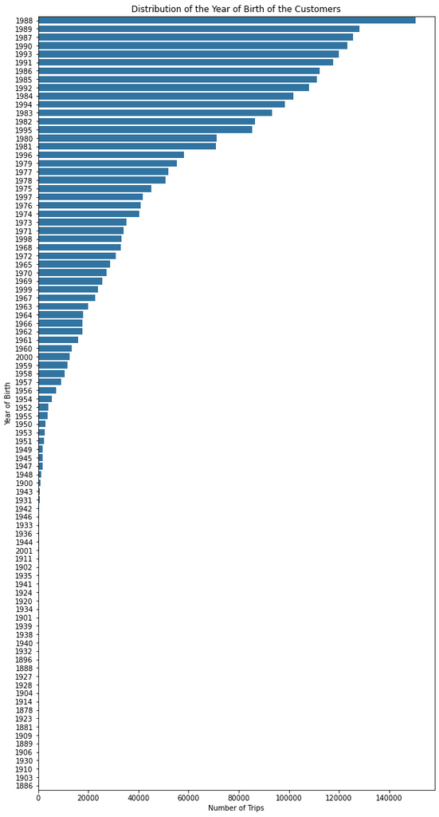

```python
# plotting the distribution of the birthyears
year_counts = df[mby].value_counts()
year_order = year_counts.index
base_color = sb.color_palette()[0]
f, ax = plt.subplots(figsize=(10, 20))
sb.countplot(data=df, y=mby, color=base_color, order=year_order)
plt.ylabel(by)
plt.xlabel(nt)
plt.title(t5);
```

> Most customers are born in the late 80s or the 90s. Other good customers are born in the late 70s. Even people born in the year 1900 are using the bike-sharing system.

### What kind of people use this bike-sharing actually?

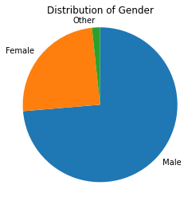

```python
# plots the Distribution of gender
draw_pie_chart(df,mg,t8)
```

> By far, males are more likely to rent a bike.

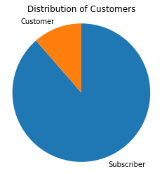

```python
# plots the Distribution of user type
draw_pie_chart(df,ut,t9)
```

> Clearly, subscribers, i.e. people with a one year subscription are more likely to grab a bike from a bike-sharing company than an *irregular* customer.

### At what hour did most users rent a bike?

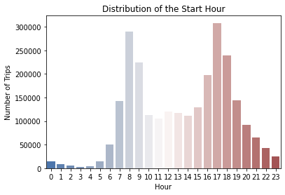

```python
# plots the distribution of the start hour
sb.countplot(data=df,palette="vlag", x=sh)
plt.ylabel(nt)
plt.xlabel(hour)
plt.title(t6);
```

> Most users rented a bike in the morning or between late afternoon and early evening hours.

### On what weekday did most users rent a bike?

```python
# number of trips per weekday
result_triple=df.groupby(sw)[swn].value_counts().loc[lambda x : x>0].to_frame()
result_triple
```

| start_weekday |  | start_weekday_name |
| --- | --- | --- |
| 0 | Monday | 406683 |
| 1 | Tuesday | 443463 |
| 2 | Wednesday | 435883 |
| 3 | Thursday | 445430 |
| 4 | Friday | 404879 |
| 5 | Saturday | 231283 |
| 6 | Sunday | 203212 |

```python
# stores the number of trips in a list
result_triple2=df.groupby(sw)[swn].value_counts().loc[lambda x : x>0].to_list()
result_triple2
```

```
[406683, 443463, 435883, 445430, 404879, 231283, 203212]
```

```python
# stores the names of each weekday in a list
result_triple3=df.groupby(sw)[swn].value_counts().loc[lambda x : x>0].index.to_list()
result_triple3
```

```
[(0, 'Monday'),
 (1, 'Tuesday'),
 (2, 'Wednesday'),
 (3, 'Thursday'),
 (4, 'Friday'),
 (5, 'Saturday'),
 (6, 'Sunday')]
```

```python
# creates list of tuples containing the weekday together with the number of trips on that day
l=get_tuple(result_triple3,result_triple2)
l
```

```
[('Monday', 406683),
 ('Tuesday', 443463),
 ('Wednesday', 435883),
 ('Thursday', 445430),
 ('Friday', 404879),
 ('Saturday', 231283),
 ('Sunday', 203212)]
```

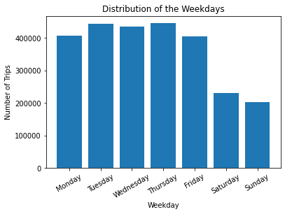

```python
# plotting a bar chart
plt.bar(range(len(l)), [val[1] for val in l], align='center')
plt.xticks(range(len(l)), [val[0] for val in l])
plt.xticks(rotation=30)
plt.xlabel(wd)
plt.ylabel(nt)
plt.title(t7)
plt.show()
```

> The period from Tuesday until Thursday contained the most bike rides with Thursday being the most active day of the week.

### In which months did most users rent a bike?

```python
# dataframe containing only the start time for the year 2017
df_2017=filter_dataframe(df,'2017-01-01','2017-12-31')
len(df_2017)
```

```
0
```

```python
# dataframe containing only the start time for the year 2018
df_2018=filter_dataframe(df,'2018-01-01','2018-12-31')
len(df_2018)
```

```
1738688
```

```python
# dataframe containing only the start time for the year 2018
df_2019=filter_dataframe(df,'2019-01-01','2019-12-31')
len(df_2019)
```

```
829277
```

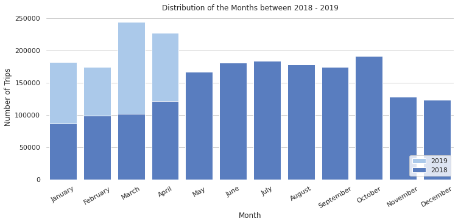

```python
# plots the months
sb.set_theme(style="whitegrid")
f, ax = plt.subplots(figsize=(12,5))

d2019=get_dict('pastel',smn,df_2019,'2019','b')
d2018=get_dict('muted',smn,df_2018,'2018','b')

dlist=[]
dlist.append(d2019)
dlist.append(d2018)

for d in dlist:
    p=d[p_label]
    xval=d[col_label]
    x=d[data_label]
    l=d[lab]
    c=d[color_label]
    draw_bar_chart(p,xval,x,l,c)

ax.legend(ncol=1, loc="lower right", frameon=True)
sb.despine(left=True, bottom=True)
ax.set(ylabel=nt,xlabel=m,title=t10)
plt.xticks(rotation=30);
```

> Between 2018 and 2019 March and April were preferred in the first half while October was the preferred month in the second half of the year.

### How long was a bike ride on average?

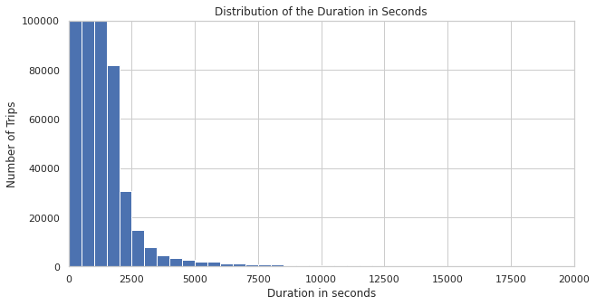

```python
# standard-scaled plot of the duration
ax1=[0, 20000, 0, 100000]
bins=get_standard_bins(0,df,ds,500)
get_standard_histogram(bins,10,5,df,ds,dst,nt,t11,ax1)
```

> There's a long tail in the distribution, so I'm going to scale the x-axis.

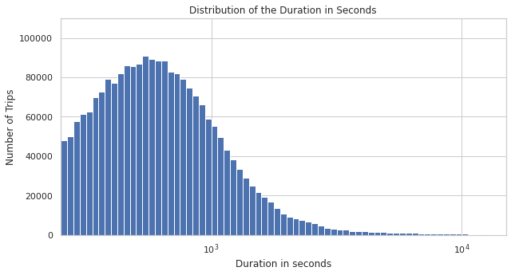

```python
# log-scaled plot of the duration
bin_size=0.025
ax1=[250, 15000, 0, 110000]
bins=get_log_bins(df,ds,bin_size)
get_log_histogram(bins,10,5,df,ds,dst,nt,t11,ax1)
```

> Looking further into the distribution of the duration of trips, most trips took less than 17 minutes, longer trips are an exception.

### Where did usually the bike rides begin and end?

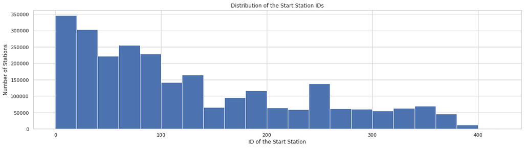

```python
# standard-scaled plot of the start station id
ax1=[]
bins=get_standard_bins(0,df,si,20)
get_standard_histogram(bins,20,5,df,si,sit,ns,t12,ax1)
```

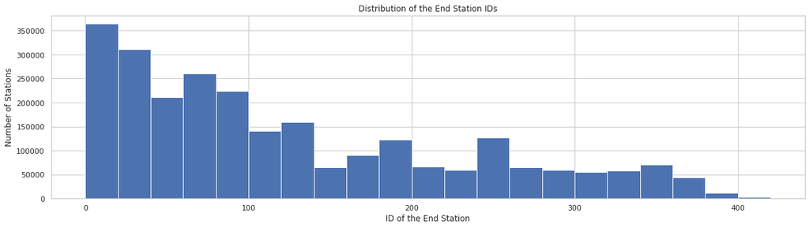

```python
# standard-scaled plot of the end station id
ax1=[]
bins=get_standard_bins(0,df,ei,20)
get_standard_histogram(bins,20,5,df,ei,eit,ns,t13,ax1)
```

> Obviously, both the distribution of the start station and end station ids aren't symmetric but skewed to the right.

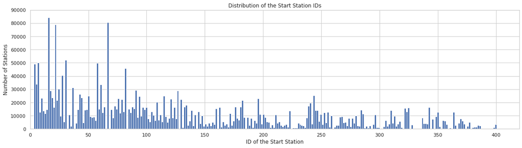

```python
# let's decrease the bin size to get a finer distribution of both the start and the end station id
max_station_id=df[si].max()
ax1=[0, max_station_id, 0, 90000]
bins=get_standard_bins(0,df,si,1.5)
get_standard_histogram(bins,20,5,df,si,sit,ns,t12,ax1)
```

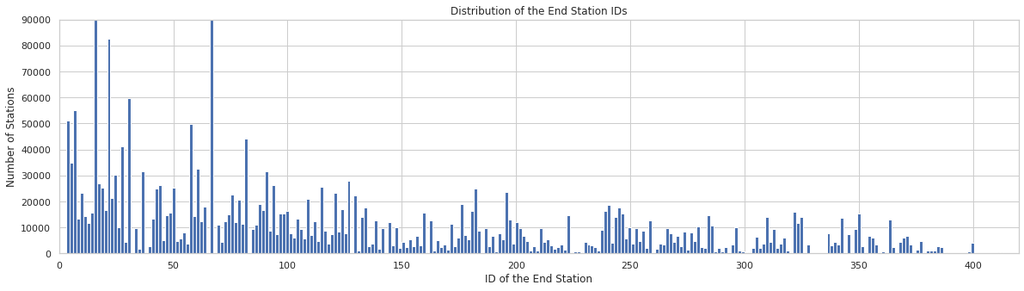

```python
# plots distribution of end stations
max_station_id=df[ei].max()
ax1=[0, max_station_id, 0, 90000]
bins=get_standard_bins(0,df,ei,1.5)
get_standard_histogram(bins,20,5,df,ei,eit,ns,t13,ax1)
```

> The charts for start station and end station ids look similar which suggests that a lot of trips were just short trips or more likely that pick up and return station are often the same.

### Discuss the distribution(s) of your variable(s) of interest. Were there any unusual points? Did you need to perform any transformations?

> The distribution of the variable `duration_sec`, i.e. the duration of a trip in seconds is quite unusual in that it is highly skewed to the right. I performed a logarithmic transformation of the x-axis to discover some trends. The transformation showed that most trips were actually quite short.

### Of the features you investigated, were there any unusual distributions? Did you perform any operations on the data to tidy, adjust, or change the form of the data? If so, why did you do this?

> The variables `start_station_id`, `end_station_id` and `member_birth_year` are numeric in nature but were stored as a float in the .csv file. So I removed the rows containing null values in these columns and converted them as an integer. Additionally, I converted the datatype of some variables such as `user_type` or `member_gender` as a category. Last but not least, I merged several csv files containing different time periods into one large csv file.

## Bivariate Exploration

### Which features have a significant influence on the duration of a trip?

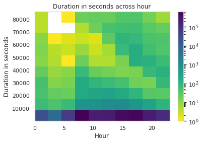

```python
# plots duration vs hour
draw_heatplot(df,sh,ds,hour,dst,t14)
```

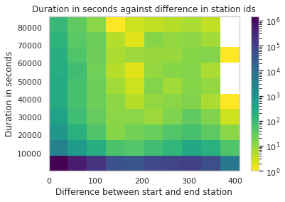

```python
# plots duration vs difference in station ids
draw_heatplot(df,dis,ds,dist,dst,t15)
```

### Which stations are among the busiest during the week?

> As my dataset contains a lot of data, let's take a look at violin plots describing the relationship between start time and the bike-sharing stations.

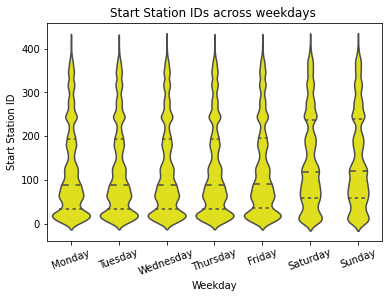

```python
# plots start station ids vs weekdays
draw_violin_plot(df,swn,si,'yellow',wd,sit,t16)
```

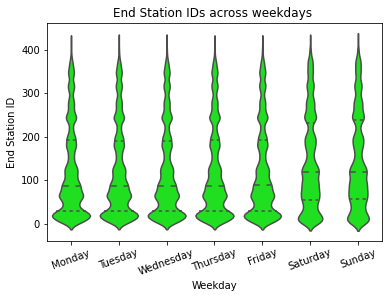

```python
# plots end station ids vs weekdays
draw_violin_plot(df,swn,ei,'lime',wd,eit,t17)
```

> Obviously, both violin maps look quite the same. Whereas during the week the stations with an id < 150 are very busy, on the weekends however also the higher ids are well frequented.

### Which start time is preferred by each customer type?

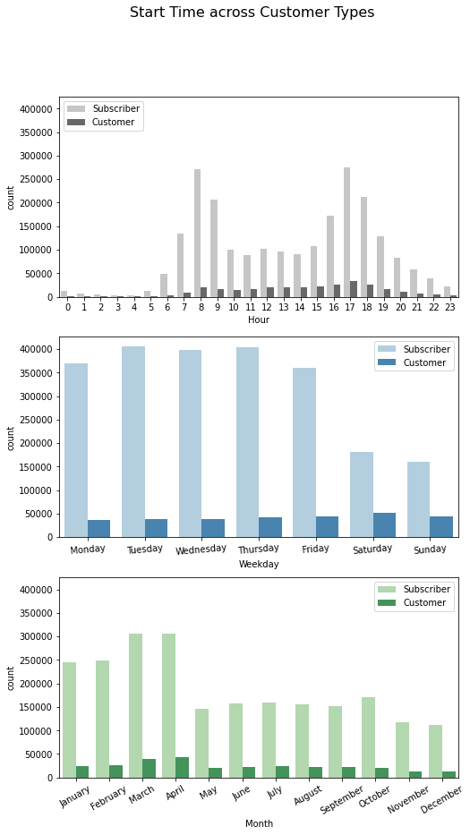

```python
# plots bar charts where start time is depicted against customer types
fig, axes = plt.subplots(3, 1, figsize=(8, 14), sharey=True)

hour_dict=get_dict2(axes[0],df,sh,ut,'Greys','upper left',1,hour,0)
wd_dict=get_dict2(axes[1],df,swn,ut,'Blues','upper right',1,wd,5)
m_dict=get_dict2(axes[2],df,smn,ut,'Greens','upper right',1,m,30)

dlist=[]
dlist.append(hour_dict)
dlist.append(wd_dict)
dlist.append(m_dict)

for d in dlist:
    p=d[p_label]
    xval=d[col_label]
    x=d[data_label]
    a=d[ax_label]
    h=d[cat_label]
    l=d[loc_label]
    n=d[ncol_label]
    xt=d[x_title]
    r=d[rot_label]
    draw_bar_chart_v2(a,x,xval,h,p,l,n,xt,r)

fig.suptitle(t18,fontsize=16)
plt.show()
```

> Both customer types prefer the same hours for a bike ride. However, there is a difference with regards to weekdays and months. Subscribers use a shared bike usually on weekdays whereas (irregular) customers rent a bike on weekends. Additionally, while both customer types prefer the same months in the first half of the year, the second half of the year differs for each customer type. Subscribers prefer October, while irregular customers prefer the summer time.

### Which start time is preferred by each gender?

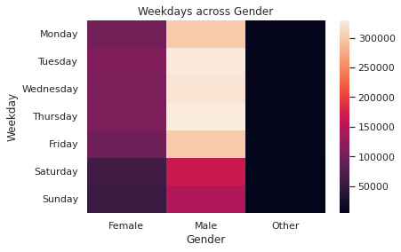

```python
# plots weekdays against gender
draw_heatplot(df,swn,mg,mgt,wd,t19)
```

> Both genders would rather have a bike ride during the week than on weekends.

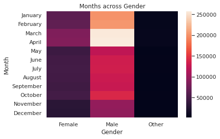

```python
# plots months against gender
draw_heatplot(df,smn,mg,mgt,m,t20)
```

> Both genders prefer the months March and April during the first half of the year, while October is the busiest month during the second half of the year.

### Talk about some of the relationships you observed in this part of the investigation. How did the feature(s) of interest vary with other features in the dataset?

> There was also an interesting relationship between the station ids and weekdays which is also logarithmic in nature. The smaller station ids are preferred during the week whereas on weekends the higher station ids are increasing.

### Did you observe any interesting relationships between the other features (not the main feature(s) of interest)?

> Both the categorical variables customer types and gender show the same preference over the start time. They both tend to start a bike ride at the same hour, weekday or month.

## Multivariate Exploration

> In this part of the analysis I want to explore how some categorical variables play into the relationship between the duration in seconds and the station id.

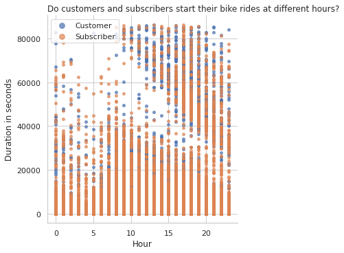

```python
# plots a regression model consisting of duration in seconds, hours and customer types
draw_regression(sh,ds,df,ut,'deep',0.7,'upper left',hour,dst,t1)
```

> Customers and Subscribers don't behave differently. Both started their trips mostly at the same hours.

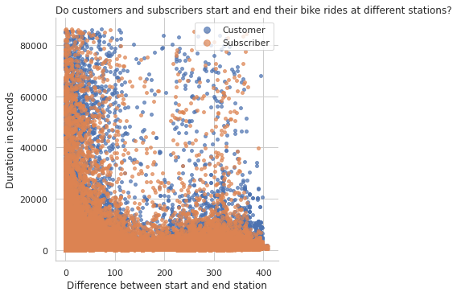

```python
# plots a regression model consisting of duration in seconds, difference in stations and customer types
draw_regression(dis,ds,df,ut,'deep',0.7,'upper right',dist,dst,t2)
```

> Both customer types started and ended their bike rides mostly at nearby stations.

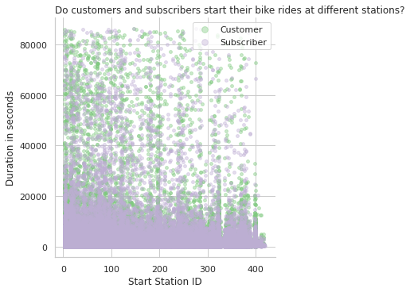

```python
# plots a regression model consisting of duration in seconds, start stations and customer types
draw_regression(si,ds,df,ut,'Accent',0.4,'upper right',sit,dst,t3)
```

> Both customer types started their bike rides at stations with ids < 150 mostly. But customers had longer bike rides than subscribers in general.

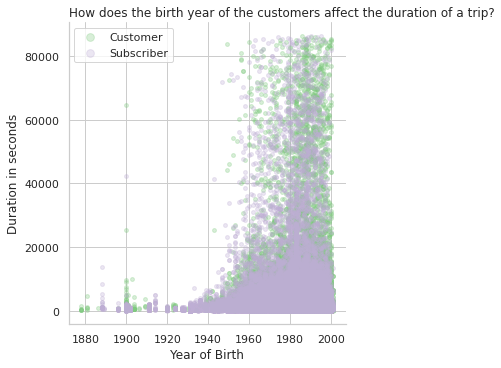

```python
# plots a regression model consisting of duration in seconds, year of birth and customer types
draw_regression(mby,ds,df,ut,'Accent',0.3,'upper left',by,dst,t4)
```

> People born between the late 70s up to the 00s have longer bike rides in general compared to older customers.

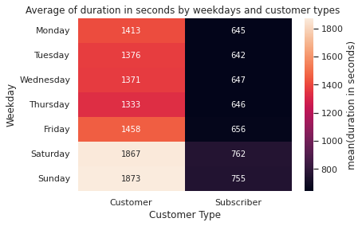

```python
# multivariate plot of average duration by weekdays and user types
val='duration_sec_avg'
means = df.groupby([swn,ut]).mean()[ds]
means = means.reset_index(name = val)
means = means.pivot(index = swn, columns = ut, values = val)
sb.heatmap(means, annot = True, fmt = '.0f', cbar_kws = {'label' : 'mean(duration in seconds)'})
plt.xlabel(cat_customer)
plt.ylabel(wd)
plt.title(t21);
```

> It's obvious from this heatmap, that customers who started their trips on weekends had longer trips in general compared to subscribers who rented their bikes for a much shorter period of time.

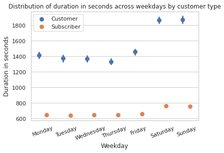

```python
# multivariate plot of duration in seconds by weekdays and user types
ax = sb.pointplot(data = df, x = swn, y = ds, hue = ut,dodge = 0.3, linestyles = "",legend=False)
ax.set(ylabel=dst,xlabel=wd)
plt.legend(loc='upper left', markerscale=1)
plt.xticks(rotation=20)
plt.title(t22);
```

> This graph shows clearly that especially on weekends customers rent their bikes for a much longer period of time compared to subscribers.

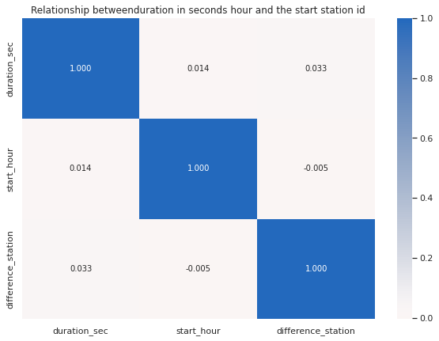

```python
# draws a correlation matrix between duration in seconds, start hour, and the difference in stations
f,ax = plt.subplots(figsize=(10,7))
sb.heatmap(df[[ds,sh,dis]].corr(), annot = True, fmt = '.3f', cmap = 'vlag_r', center = 0)
plt.title(t23);
```

> There's little up to no linear correlation between the three numeric variables.

### Talk about some of the relationships you observed in this part of the investigation. Were there features that strengthened each other in terms of looking at your feature(s) of interest?

> I extended my investigation of the duration in seconds against start and end station ids in this section by looking at the impact of start time and user type features. The multivariate exploration here showed that there is an effect of the user type on these variables because the lower the station id the higher the duration in seconds. This relationship is shown when taking the user type feature into account as both prefer the lower station ids.

### Were there any interesting or surprising interactions between features?

> Plotting the relationship of duration in seconds against the weekdays while taking the user type into account showed that the average duration of a rented bike is much higher regarding customers compared to subscribers. Apart from this, I found out that my main numeric variables of interest, namely the duration in seconds, start hour as well as the station ids have absolutely no linear relationship.

## Insights

**(I)** Most trips are taken in the morning or afternoon until early evening hours.

**(II)** While customers would rather start their trips on weekends, subscribers clearly prefer to rent a bike during the work week.

**(III)** Between 2018 and 2019 the months March, April and October were the busiest ones.

**(IV)** While the average trip takes roughly 13 minutes, this is true for subscribers who rent a bike on weekends. If customers take a trip with a shared bike on weekends then the average duration increases to about 32 minutes.